# perguntas_pt-br

Leandro Fermino Uchôa

2024-08-22

# Introdução

Olá, meu nome é Leandro Fermino Uchôa e este documento faz parte do meu projeto de conclusão de curso para o Certificado Profissional Google Data Analytics, oferecido pela Google através da plataforma Coursera [(link do curso)](https://www.coursera.org/professional-certificates/analise-de-dados-do-google). O objetivo deste projeto é analisar o desempenho e as características dos veículos no jogo “Dakar Desert Rally” [(site oficial)](https://www.dakarthegame.com/en/), utilizando dados detalhados para identificar quais veículos têm o melhor desempenho e como essas características influenciam o preço e a escolha dos jogadores.

## Sobre o Jogo

“Dakar Desert Rally” é um jogo de corrida que simula o famoso rali Dakar, oferecendo uma experiência realista e desafiadora para os jogadores. A versão do jogo utilizada para esta análise inclui o jogo base e a DLC “Dakar Desert Rally - SnowRunner Cars Pack”.

## Objetivo do Projeto

O objetivo deste projeto é: - Identificar quais veículos têm o melhor desempenho em termos de velocidade, durabilidade e outras características. - Analisar como essas características influenciam o preço e a escolha dos jogadores. - Fornecer insights que possam ajudar a melhorar o balanceamento dos veículos no jogo, informar decisões sobre atualizações e novos lançamentos, e desenvolver estratégias de marketing mais eficazes.

## Estrutura do Documento

Este documento está estruturado da seguinte forma: 1. **Perguntas de Orientação**: Questões que guiam a análise. 2. **Principais Tarefas**: Tarefas necessárias para alcançar os objetivos do projeto. 3. **Entrega**: Declaração clara da tarefa de negócios e os insights obtidos. 4. **Referências**: Fontes de dados e informações utilizadas no projeto.

## Contato

- **Nome**: Leandro Fermino Uchôa
- **LinkedIn**: [Leandro Fermino Uchôa](https://www.linkedin.com/in/lfuchoa/)

### Fase 1: Perguntas de orientação:

1. **Qual tema você está explorando?**
   - **Tema**: Análise de desempenho e características dos veículos no jogo “Dakar Desert Rally” [(site oficial)](https://www.dakarthegame.com/en/).
2. **Qual é o problema que você está tentando resolver?**
   - **Problema**: Identificar quais veículos têm o melhor desempenho em termos de velocidade, durabilidade e outras características, e como essas características influenciam o preço e a escolha dos jogadores.
3. **Quais métricas você usará para medir seus dados a fim de alcançar seu objetivo?**
   - **Métricas**:
     - Velocidade (Speed)
     - Aceleração (Acceleration)
     - Manuseio (Handling)
     - Durabilidade (Durability)
     - Potência (Power_hp)
     - Torque (Torque_Nm)
     - Velocidade Máxima (Top_Speed_km_h)
     - Preço (Price_DP)
4. **Quem são as partes interessadas?**
   - **Partes interessadas**:
     - Gerentes de produto
     - Desenvolvedores de jogos
     - Analistas de dados
     - Jogadores
     - Equipe de marketing
5. **Quem é seu público-alvo?**
   - **Público-alvo**:
     - Gerentes de produto
     - Desenvolvedores de jogos
     - Analistas de dados
     - Jogadores
     - Outros stakeholders interessados em melhorar o desempenho e a experiência dos veículos no jogo.
6. **Como seus insights podem ajudar seu cliente a tomar decisões?**
   - **Ajuda na tomada de decisões**:
     - Melhorar o balanceamento dos veículos no jogo.
     - Informar decisões sobre atualizações e novos lançamentos de veículos.
     - Otimizar a experiência do jogador.
     - Desenvolver estratégias de marketing mais eficazes.

#### Principais tarefas:

1. **Identificar a tarefa de negócios**:
   - **Tarefa de negócios**: Analisar os dados dos veículos do jogo “Dakar Desert Rally” para identificar insights sobre desempenho, características e possíveis melhorias.
2. **Determinar as principais partes interessadas**:
   - **Principais partes interessadas**: Gerentes de produto, desenvolvedores de jogos, analistas de dados, jogadores, equipe de marketing.
3. **Escolher um conjunto de dados**:
   - **Conjunto de dados**: Conjunto de dados detalhado sobre os veículos do jogo “Dakar Desert Rally” [(DDR_Vehicles_List_Statsf)](https://docs.google.com/spreadsheets/d/1j0BqVWwg1OkH2lJUIPKKPCIlDCHA7fQ124iqvNppVgw/edit?usp=sharing), extraído do link Google Sheets disponibilizado pelo usuário “faminho” [(perfil Steam)](https://steamcommunity.com/id/faminho) numa publicação na comunidade do jogo.
4. **Estabelecer métricas**:
   - **Métricas**: Velocidade, aceleração, manuseio, durabilidade, potência, torque, velocidade máxima, preço.

#### Entrega:

**Declaração clara da tarefa de negócios**: - **Tarefa de negócios**: Analisar os dados dos veículos do jogo “Dakar Desert Rally” para identificar insights sobre desempenho, características e possíveis melhorias. O objetivo é entender quais veículos têm o melhor desempenho e como suas características influenciam o preço e a escolha dos jogadores, ajudando a empresa a tomar decisões informadas sobre balanceamento, atualizações e estratégias de marketing.

### Fase 2: Preparação dos Dados

#### 1. Onde seus dados estão localizados?

Os dados estão localizados em um arquivo CSV que foi importado para o RStudio. O arquivo foi originalmente verificado e limpo no Excel antes de ser exportado para o RStudio.

#### 2. Como os dados são organizados?

Os dados estão organizados em um formato amplo (wide format), onde cada linha representa um veículo e cada coluna representa um atributo específico desse veículo.

#### 3. Existem problemas com viés ou credibilidade nesses dados? Seus dados são confiáveis, originais, abrangentes, atuais e incluem a fonte?

Os dados são provenientes do jogo [“Dakar Desert Rally”](https://www.dakarthegame.com/en/) lançado em 4/out./2022. De forma que ainda são abrangentes e atuais, ainda mais considerando o próprio universo do jogo. Quanto à integridade e abrangência, ambas já foram revisadas para garantir que não há viés.

#### 4. Como você está lidando com o licenciamento, a privacidade, a segurança e a acessibilidade?

Os dados são de um jogo, então estamos respeitando os termos de uso e licenciamento do jogo. Não há dados pessoais sensíveis, então a privacidade e a segurança são menos preocupantes aqui.

#### 5. Como você verificou a integridade dos dados?

A integridade dos dados foi assegurada através de uma verificação detalhada no Excel. Neste processo, eliminei valores ausentes e duplicados, removi espaços em branco desnecessários no início e no fim das células, e padronizei os nomes das colunas para garantir consistência. É importante destacar que o campo ‘Price_DP’ contém valores ‘NA’ de forma intencional, visando uma análise mais eficaz do conjunto de dados. Segue o código utilizado para verificar a integridade dos dados no ambiente R:

```r
# Verificar valores ausentes
sum(is.na(DDR_Vehicles_List_Stats_df))
```

```
## [1] 18
```

```r
# Verificar duplicados
sum(duplicated(DDR_Vehicles_List_Stats_df))
```

```
## [1] 0
```

#### Entrega:

**Uma descrição de todas as fontes de dados usadas**: - **Fontes Usadas**: As fontes utilizadas incluem o site oficial do jogo e a planilha de dados disponibilizada pelo usuário ‘faminho’ na página da comunidade do jogo, na plataforma Steam.

#### Referências

- [Site oficial do jogo “Dakar Desert Rally”](https://www.dakarthegame.com/en/)
- [Google Sheets - Conjunto de dados originais](https://docs.google.com/spreadsheets/d/1j0BqVWwg1OkH2lJUIPKKPCIlDCHA7fQ124iqvNppVgw/edit?usp=sharing)
- [Perfil Steam do usuário “faminho”](https://steamcommunity.com/id/faminho)
- [Publicação na comunidade do jogo no Steam](https://steamcommunity.com/sharedfiles/filedetails/?id=2893717112)

### Fase 3: Processar os Dados

#### 1. Quais ferramentas você está escolhendo e por quê?

Estou utilizando o Excel para a limpeza inicial dos dados e o R com os pacotes `dplyr` e `tidyr` para manipulação e confirmação da limpeza dos dados. O Excel é uma ferramenta intuitiva e eficaz para limpeza de dados, enquanto o R é poderoso para manipulação de dados e verificação de integridade.

#### 2. Você garantiu a integridade dos seus dados?

Sim, a integridade dos dados foi garantida através de verificações detalhadas no Excel, onde removi valores ausentes e duplicados, e padronizei os nomes das colunas. Posteriormente, confirmei a integridade dos dados no R.

#### 3. Que medidas foram tomadas para garantir que seus dados estejam limpos?

No Excel, removi valores ausentes e duplicados, eliminei espaços em branco desnecessários e padronizei os nomes das colunas. No R, utilizei funções para verificar a ausência de valores ausentes e duplicados, e para garantir a consistência dos dados.

#### 4. Como você pode verificar se seus dados estão limpos e prontos para análise?

Verificando a ausência de valores ausentes e duplicados no R, e utilizando funções de resumo para garantir que os dados estão consistentes e prontos para análise.

#### 5. Você documentou seu processo de limpeza para poder revisar e compartilhar esses resultados?

Sim, todo o processo de limpeza foi documentado no Excel e confirmado no código RMarkdown, permitindo revisão e compartilhamento dos resultados.

#### Entrega:

Documentação de Limpeza e Manipulação de Dados

#### Introdução

O objetivo deste documento é descrever o processo de limpeza e manipulação dos dados do jogo “Dakar Desert Rally”. A limpeza dos dados foi realizada no Excel, e a confirmação da integridade dos dados foi feita no RStudio.

#### Ferramentas Utilizadas

- **Excel**: Utilizado para a limpeza inicial dos dados.
- **RStudio**: Utilizado para confirmar a integridade dos dados.
- **Pacotes R**: `dplyr`, `tidyr`

#### Passos de Limpeza e Manipulação

1. **Importação dos Dados**
   - Os dados foram importados para o Excel a partir de uma planilha Google Sheets.
2. **Remoção de Valores Ausentes**
   - Valores ausentes foram identificados e removidos para garantir a integridade dos dados.
3. **Remoção de Duplicados**
   - Linhas duplicadas foram removidas para evitar redundâncias.
4. **Eliminação de Espaços em Branco**
   - Espaços em branco desnecessários no início e no fim das células foram eliminados.
5. **Padronização dos Nomes das Colunas**
   - Os nomes das colunas foram padronizados para garantir consistência.
6. **Exportação dos Dados**
   - Os dados limpos foram exportados para um arquivo CSV.
7. **Confirmação da Limpeza no RStudio**
   - O arquivo CSV foi importado para o RStudio para confirmar a limpeza dos dados

### Fase 4: Analisar os Dados

#### 1. Resumo Descritivo das Principais Medidas de um Conjunto de Dados:

Neste resumo descritivo, apresento as principais medidas de um conjunto de dados, incluindo mínimo, primeiro quartil, mediana, média, terceiro quartil e máximo:

- **Min. (Mínimo)**: O menor valor no conjunto de dados.
- **1st Qu. (Primeiro Quartil)**: O valor abaixo do qual 25% dos dados se encontram.
- **Median (Mediana)**: O valor central que divide o conjunto de dados em duas metades iguais.
- **Mean (Média)**: A média aritmética dos valores.
- **3rd Qu. (Terceiro Quartil)**: O valor abaixo do qual 75% dos dados se encontram.
- **Max. (Máximo)**: O maior valor no conjunto de dados.

Esses valores ajudam a entender a distribuição dos dados, mostrando a tendência central e a dispersão.

```r
# Resumo Estatístico:
summary(DDR_Vehicles_List_Stats_df)
```

```
##  Vehicle_Type         Category            Number             Driver
##  Length:277         Length:277         Length:277         Length:277
##  Class :character   Class :character   Class :character   Class :character
##  Mode  :character   Mode  :character   Mode  :character   Mode  :character
##
##
##
##
##  Drivers_Country       Brand              Model               Team
##  Length:277         Length:277         Length:277         Length:277
##  Class :character   Class :character   Class :character   Class :character
##  Mode  :character   Mode  :character   Mode  :character   Mode  :character
##
##
##
##
##    Team_Score         Speed         Acceleration       Handling
##  Min.   : 1.000   Min.   : 3.000   Min.   : 3.000   Min.   : 4.000
##  1st Qu.: 5.000   1st Qu.: 5.000   1st Qu.: 6.000   1st Qu.: 7.000
##  Median : 5.000   Median : 6.000   Median : 7.000   Median : 8.000
##  Mean   : 5.448   Mean   : 6.123   Mean   : 7.227   Mean   : 7.552
##  3rd Qu.: 6.000   3rd Qu.: 7.000   3rd Qu.: 8.000   3rd Qu.: 8.000
##  Max.   :10.000   Max.   :10.000   Max.   :10.000   Max.   :10.000
##
##    Durability      Drivetrain          Length_mm       Width_mm
##  Min.   : 1.000   Length:277         Min.   :1482   Min.   : 800
##  1st Qu.: 2.000   Class :character   1st Qu.:2191   1st Qu.:1171
##  Median : 5.000   Mode  :character   Median :3825   Median :1925
##  Mean   : 4.913                      Mean   :3817   Mean   :1726
##  3rd Qu.: 7.000                      3rd Qu.:4690   3rd Qu.:2200
##  Max.   :10.000                      Max.   :7100   Max.   :2550
##
##    Height_mm     Wheelbase_mm     Engine             Power_hp
##  Min.   : 960   Min.   :1280   Length:277         Min.   :  28.0
##  1st Qu.:1271   1st Qu.:1535   Class :character   1st Qu.:  68.0
##  Median :1740   Median :2591   Mode  :character   Median : 195.0
##  Mean   :1818   Mean   :2614                      Mean   : 341.1
##  3rd Qu.:1910   3rd Qu.:3060                      3rd Qu.: 375.0
##  Max.   :3550   Max.   :4300                      Max.   :1250.0
##
##    Torque_Nm      Top_Speed_km_h     Price_DP       Source
##  Min.   :  45.0   Min.   :154.0   Min.   : 110   Length:277
##  1st Qu.:  47.7   1st Qu.:178.0   1st Qu.: 655   Class :character
##  Median : 200.0   Median :194.0   Median :1400   Mode  :character
##  Mean   : 918.5   Mean   :191.6   Mean   :1965
##  3rd Qu.: 700.0   3rd Qu.:203.0   3rd Qu.:2700
##  Max.   :5000.0   Max.   :225.0   Max.   :9999
##                                   NA's   :18
##  Full_Stats_No_TS Full_Stats_With_TS
##  Min.   :15.00    Min.   :20.00
##  1st Qu.:23.00    1st Qu.:28.00
##  Median :26.00    Median :31.00
##  Mean   :25.82    Mean   :31.26
##  3rd Qu.:28.00    3rd Qu.:34.00
##  Max.   :31.00    Max.   :40.00
##
```

#### 2. Resumo Descritivo das Principais Medidas de um Conjunto de Dados:

Um dos fatores que me levaram a trabalhar com este conjunto de dados é minha paixão por jogos de corrida, especialmente por ser jogador deste jogo em particular. Como jogador, uma das perguntas que sempre faço, e sei que outros jogadores também fazem, é: “Qual é o melhor carro?”

Com isso em mente, não tive dúvidas: essa era a grande pergunta que queria responder. Aqui está a resposta.

```r
datatable(best_vehicles_per_vehicle_type, options = list(
  autoWidth = TRUE,
  scrollX = TRUE,
  scrollY = "400px",  # Ajuste a altura conforme necessário
  paging = FALSE  # Desativa a paginação para mostrar todas as linhas
))
```

|  | Vehicle_Type | Category | Number | Driver | Drivers_Country | Brand | Model | Team | Full_Stats_No_TS | Handling | Acceleration | Speed | Durability | Price_DP |
| --- | --- | --- | --- | --- | --- | --- | --- | --- | --- | --- | --- | --- | --- | --- |
| 1 | Bikes | Dakar 22 | 1 | Kevin Benavides | Argentina | KTM | 450 Rally Factory Replica | Red Bull KTM Factory Racing | 29 | 8 | 9 | 8 | 4 | 2700 |
| 2 | Bikes | Dakar 22 | 52 | Mathias Walkner | Austria | KTM | 450 Rally Factory Replica | Red Bull KTM Factory Racing | 29 | 8 | 9 | 8 | 4 | 3300 |
| 3 | Bikes | Dakar 22 | 18 | Toby Price | Australia | KTM | 450 Rally Factory Replica | Red Bull KTM Factory Racing | 29 | 8 | 9 | 8 | 4 | 4000 |
| 4 | Cars | Dakar 22 | 209 | Martin Prokop | Czech Republic | Ford | Raptor Cross Country RS T1+ | Benzina Orlen Team | 31 | 9 | 8 | 7 | 7 | 4200 |
| 5 | Quads | Dakar 20 | 250 | Ignacio Casale | Chile | Yamaha | Raptor 700 | Casale Racing | 19 | 6 | 8 | 3 | 2 | 1500 |
| 6 | SxS | Dakar 20 | 418 | Graham Knight | United Kingdom | Polaris | RZR 1000 Turbo | XtremePlus Polaris Factory Team | 23 | 9 | 6 | 4 | 4 | 1000 |
| 7 | SxS | Dakar 20 | 406 | Jose Luis Pena Campo | Spain | Polaris | RZR 1000 Turbo | XtremePlus Polaris Factory Team | 23 | 9 | 6 | 4 | 4 | 1500 |
| 8 | SxS | Dakar 20 | 424 | Eric Abel | France | Polaris | RZR 1000 Turbo | XtremePlus Polaris Factory Team | 23 | 9 | 6 | 4 | 4 | 1500 |
| 9 | SxS | Dakar 22 | 423 | Michelle Cinotto | Italy | Polaris | RZR PRO XP | XtremePlus Polaris Factory Team | 23 | 9 | 6 | 4 | 4 | 2400 |
| 10 | SxS | Dakar 22 | 437 | Pietro Cinotto | Italy | Polaris | RZR PRO XP | XtremePlus Polaris Factory Team | 23 | 9 | 6 | 4 | 4 | 2700 |

[output cut: 4 more lines]

#### 3. Análise da Proporção de Tipos de Veículos:

Nesta análise, apresentamos uma representação visual que ilustra a proporção de diferentes tipos de veículos (`Vehicle_Type`) no jogo como um todo. Cada “fatia” do gráfico representa um tipo de veículo (`Vehicle_Type`), e seu tamanho é proporcional ao percentual dessa categoria em relação ao total.

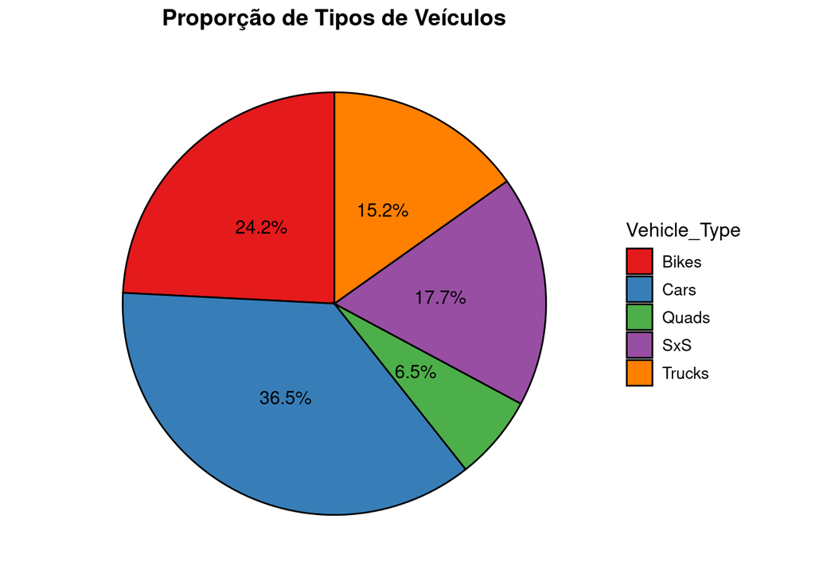

```r
# Criar o dataframe total_veiculos_tipo a partir do DDR_Vehicles_List_Stats_df
total_veiculos_tipo <- DDR_Vehicles_List_Stats_df %>%
  group_by(Vehicle_Type) %>%
  summarise(n = n()) %>%
  mutate(percentage = (n / sum(n)) * 100)

# Gráfico de Pizza mostrando a contribuição dos tipos de veiculos no total
ggplot(total_veiculos_tipo, aes(x = "", y = n, fill = Vehicle_Type)) +
  geom_bar(width = 1, stat = "identity", color = "black") +
  coord_polar("y", start = 0) +
  scale_fill_brewer(palette = "Set1") +
  geom_text(aes(label = paste0(round(percentage, 1), "%")),
            position = position_stack(vjust = 0.5), size = 4) +
  ggtitle("Proporção de Tipos de Veículos") +
  theme_minimal() +
  theme(
    plot.title = element_text(hjust = 0.5, size = 14, face = "bold"),
    axis.title = element_blank(),
    axis.text = element_blank(),
    axis.ticks = element_blank(),
    panel.grid = element_blank(),
    legend.title = element_text(size = 12),
    legend.text = element_text(size = 10)
  )
```